# Casual Inference Notebook

## Propensity score matching

Fit a propensity score model to predict treatment (not the outcome!). Use logistic regression with glm

```r
print("===================================================")
```

```
## [1] "==================================================="
```

```r
# now the outcome variable is treatment (treatment.swang), not outcome.died since we're modeling "who was likely to receive RHC, given their covariates". "~ ." includes all other variables as predictors (besides what we're modeling).
psmodel <- glm(treatment.swang ~ ., family = binomial, data = rhc.selected[, c(xvars, "treatment.swang")])# => Use the variables we found before in xvars in the first assignment to predict treatment

summary(psmodel)   # show coefficients etc
```

```
##
## Call:
## glm(formula = treatment.swang ~ ., family = binomial, data = rhc.selected[,
##     c(xvars, "treatment.swang")])
##
## Coefficients:
##                   Estimate Std. Error z value Pr(>|z|)
## (Intercept)      9.1435181  2.8001589   3.265 0.001093 **
## ARF             -0.1993146  0.0790906  -2.520 0.011733 *
## CHF              0.1105408  0.1506968   0.734 0.463235
## Cirrhosis       -1.4265886  0.2289511  -6.231 4.64e-10 ***
## Coma            -0.7781231  0.1655087  -4.701 2.58e-06 ***
## Lung.Cancer     -0.8240366  0.5053386  -1.631 0.102962
## MOSF.Malignancy -0.2802613  0.1475816  -1.899 0.057561 .
## cardiohx         0.0994467  0.0900903   1.104 0.269656
## chfhx           -0.0015423  0.0982163  -0.016 0.987471
## dementhx        -0.4737206  0.1143868  -4.141 3.45e-05 ***
## psychhx         -0.4843293  0.1318953  -3.672 0.000241 ***
## chrpulhx        -0.2169838  0.0903336  -2.402 0.016304 *
## renalhx         -0.3680069  0.1724127  -2.134 0.032806 *
## liverhx         -0.2261681  0.1701381  -1.329 0.183742
## malighx         -0.2885066  0.0871562  -3.310 0.000932 ***
## immunhx          0.0148209  0.0700495   0.212 0.832437
## transhx          0.5068504  0.0935418   5.418 6.01e-08 ***
## age              0.0009015  0.0020687   0.436 0.663000
## edu              0.0311376  0.0098326   3.167 0.001541 **
## das2d3pc         0.0063801  0.0062066   1.028 0.303973
## aps1             0.0180990  0.0022395   8.082 6.38e-16 ***
## scoma1          -0.0008406  0.0012483  -0.673 0.500704
## meanbp1         -0.0073053  0.0009272  -7.879 3.31e-15 ***
## wblc1            0.0017317  0.0025814   0.671 0.502322
## temp1           -0.0084141  0.0182504  -0.461 0.644773
## alb1            -0.1039610  0.0459299  -2.263 0.023607 *
## hema1           -0.0180316  0.0043474  -4.148 3.36e-05 ***
## bili1            0.0035635  0.0070830   0.503 0.614897
## crea1            0.0224782  0.0203248   1.106 0.268750
## pot1            -0.1689508  0.0320553  -5.271 1.36e-07 ***
## paco21          -0.0188045  0.0032662  -5.757 8.55e-09 ***
## ph1             -1.1484028  0.3601799  -3.188 0.001431 **
## wtkilo1          0.0071622  0.0011498   6.229 4.69e-10 ***
## dnr1            -0.7060266  0.1101245  -6.411 1.44e-10 ***
## resp            -0.1985399  0.0752337  -2.639 0.008316 **
## card             0.6931842  0.0780785   8.878  < 2e-16 ***
## gastr            0.4735664  0.0991902   4.774 1.80e-06 ***
## renal            0.2907049  0.1427665   2.036 0.041728 *
## hema            -0.5385458  0.1394851  -3.861 0.000113 ***
## seps             0.2352497  0.0864182   2.722 0.006484 **
## trauma           1.3864699  0.3167119   4.378 1.20e-05 ***
## ---
## Signif. codes:  0 '***' 0.001 '**' 0.01 '*' 0.05 '.' 0.1 ' ' 1
##
## (Dispersion parameter for binomial family taken to be 1)
##
##     Null deviance: 7621.4  on 5734  degrees of freedom
## Residual deviance: 6463.1  on 5694  degrees of freedom
## AIC: 6545.1
##
## Number of Fisher Scoring iterations: 4
```

```r
pscore<-psmodel$fitted.values # create propensity score

print("===================================================")
```

```
## [1] "==================================================="
```

# Now it is time to check the positivity assumption

# let’s check the overlap/positivity between the propensity scores for the two groups. We do that before the matching.

```r
print("===================================================")
```

```
## [1] "==================================================="
```

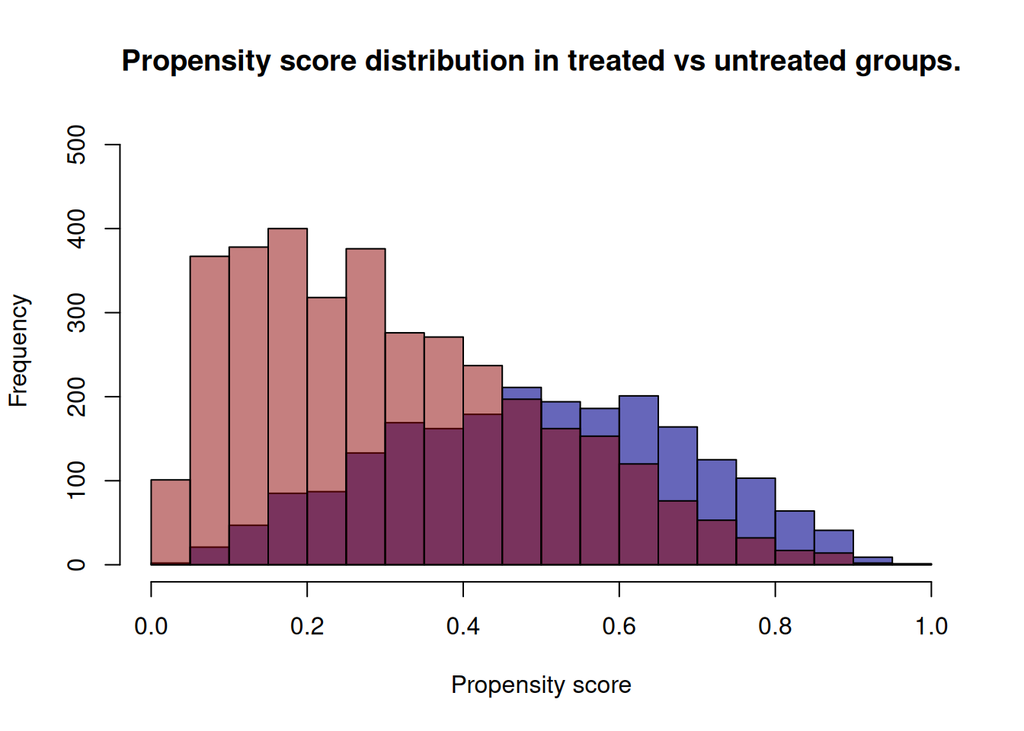

```r
#  => plot the density of the propensity scores of the treated and untreated. Tip: you might want to use par(mfrow=c(2,1)) to create 2 panels (2 rows, 1 column) and then plotting the first hist (histogram), with say, ylim=c(0,650) and col='darkblue', and the second histogram with ylim=c(650, 0) (note that we flipped the order) and col='darkblue'. This will plot the blue histogram as a normal histogram and the red one will be plotted upside down underneath the blue one so you can easily see the overlap/positivity.


brks <- seq(0, 1, 0.05)
ymax <- max(hist(pscore, breaks = brks, plot = FALSE)$counts)
#Plot propensity score frequencies for treated and untreated groups to check for overlap/positivity
hist(pscore[rhc.selected$treatment.swang == 1], breaks = brks, col = rgb(0, 0, 0.55, 0.6),
     xlab = "Propensity score", main = "Propensity score distribution in treated vs untreated groups.", ylim = c(0, ymax)) #Use transparansy of 0.6/0.5 to overlap/positivity them nicely
hist(pscore[rhc.selected$treatment.swang == 0], breaks = brks, col = rgb(0.55, 0, 0, 0.5), add = TRUE) #Add to previous histogram to merge them into one overlap/positivityping histogram
```

```r
# => What do you think about the overlap/positivity?
# Across most of the range of propensity scores there is substantial overlap/positivity (between 0.1 and 0.8), there exist comparable treated and untreated subjects to match at most points along the score. Only below 0.1 and between 0.8-0.9, there is little overlap/positivity, indicating a possible positivity violation in those small regions, which risks no valid comparison and thus few matches in those regions (since we will be using a caliper to ensure we avoid poor, distant matches). However, since this is real RHC data, we expected this decent but imperfect overlap/positivity in the tails, since, as we observed before, there simply are significantly more deaths (and thus higher propensity scores) in the treated group. In conclusion, the positivity assumption is okay here, but we note a possible limitation in the tails.


print("===================================================")
```

```
## [1] "==================================================="
```

We want to do greedy matching on PS using Match with a caliper. Note that instead of the probability PS itself, we usually use the log odds (logit) of PS which is log(PS/(1-PS)) which is also equal to log(PS)-log(1-PS) . So let us first write a function (of one line) to calculate the logit.

```r
print("===================================================")
```

```
## [1] "==================================================="
```

```r
logit <- function(p) {log(p/(1-p))} # => Complete this function to calculate the log odds
print("===================================================")
```

```
## [1] "==================================================="
```

Now we want to use Match() with rhc.selected$treatment.swang as treatement, with 1 matched control per treated subject, with X as the logit(pscore), with no replacement and with a caliper of 0.2

```r
print("===================================================")
```

```
## [1] "==================================================="
```

```r
#Match() function has to randomly chose between equal best matches when replacement = False. Note that this is much more likely here than before since now we are only matching on 1 variable (propensity) rather than all the variables in xvars. Thus, set seed for reproducibility of results.
set.seed(42)

# Compute all logits
logits <- sapply(pscore, logit)

#psmatch <- Match(Tr=mydata$treatment,...) # => complete the command

psmatch <- Match(Tr = rhc.selected$treatment.swang, M = 1, X = logits,
                      replace = FALSE, Weight = 2, caliper = 0.2)
print("===================================================")
```

```
## [1] "==================================================="
```

```r
matched_ps <- rhc.selected[unlist(psmatch[c("index.treated","index.control")]), ]
```

## Get standardized differences. Note: xvars is the same as in the first assignment.

```r
print("===================================================")
```

```
## [1] "==================================================="
```

```r
matchedtab1_ps <- CreateTableOne(vars=xvars, strata ="treatment.swang",
                            data=matched_ps, test = FALSE) # => Complete the command
# => print the matching table showing the SMD
print(matchedtab1_ps, smd=TRUE)
```

```
##                              Stratified by treatment.swang
##                               0             1             SMD
##   n                            1734          1734
##   ARF (mean (SD))              0.45 (0.50)   0.44 (0.50)   0.035
##   CHF (mean (SD))              0.10 (0.30)   0.10 (0.30)   0.002
##   Cirrhosis (mean (SD))        0.03 (0.17)   0.03 (0.16)   0.007
##   Coma (mean (SD))             0.05 (0.22)   0.05 (0.21)   0.016
##   Lung.Cancer (mean (SD))      0.00 (0.06)   0.00 (0.05)   0.020
##   MOSF.Malignancy (mean (SD))  0.08 (0.27)   0.08 (0.27)   0.002
##   cardiohx (mean (SD))         0.21 (0.40)   0.20 (0.40)   0.017
##   chfhx (mean (SD))            0.20 (0.40)   0.20 (0.40)  <0.001
##   dementhx (mean (SD))         0.07 (0.26)   0.07 (0.26)  <0.001
##   psychhx (mean (SD))          0.05 (0.23)   0.05 (0.22)   0.013
##   chrpulhx (mean (SD))         0.15 (0.36)   0.16 (0.36)   0.005
##   renalhx (mean (SD))          0.05 (0.22)   0.05 (0.22)   0.013
##   liverhx (mean (SD))          0.07 (0.25)   0.06 (0.25)   0.005
##   malighx (mean (SD))          0.22 (0.42)   0.22 (0.41)   0.014
##   immunhx (mean (SD))          0.30 (0.46)   0.28 (0.45)   0.025
##   transhx (mean (SD))          0.12 (0.32)   0.13 (0.34)   0.033
##   age (mean (SD))             61.09 (17.41) 60.85 (15.62)  0.015
##   edu (mean (SD))             11.82 (3.23)  11.77 (3.18)   0.016
##   das2d3pc (mean (SD))        20.59 (5.60)  20.65 (5.03)   0.012
##   aps1 (mean (SD))            57.54 (19.36) 57.40 (19.24)  0.007
##   scoma1 (mean (SD))          18.81 (28.81) 18.65 (27.92)  0.005
##   meanbp1 (mean (SD))         72.27 (34.69) 72.82 (35.41)  0.016
##   wblc1 (mean (SD))           15.95 (12.67) 15.83 (12.52)  0.010
##   temp1 (mean (SD))           37.67 (1.90)  37.63 (1.75)   0.021
##   alb1 (mean (SD))             3.03 (0.72)   3.03 (0.95)   0.007
##   hema1 (mean (SD))           30.74 (8.21)  30.88 (7.51)   0.019
##   bili1 (mean (SD))            2.51 (5.48)   2.49 (4.98)   0.003
##   crea1 (mean (SD))            2.32 (2.38)   2.32 (2.00)  <0.001
##   pot1 (mean (SD))             4.05 (1.06)   4.05 (1.00)   0.002
##   paco21 (mean (SD))          37.06 (10.63) 37.40 (11.26)  0.031
##   ph1 (mean (SD))              7.39 (0.11)   7.39 (0.11)   0.009
##   wtkilo1 (mean (SD))         70.56 (25.52) 70.84 (27.25)  0.011
##   dnr1 (mean (SD))             0.09 (0.28)   0.08 (0.28)   0.015
##   resp (mean (SD))             0.33 (0.47)   0.33 (0.47)   0.009
##   card (mean (SD))             0.40 (0.49)   0.40 (0.49)   0.005
##   gastr (mean (SD))            0.18 (0.38)   0.18 (0.38)   0.003
##   renal (mean (SD))            0.06 (0.24)   0.06 (0.24)   0.007
##   hema (mean (SD))             0.06 (0.24)   0.06 (0.24)   0.005
##   seps (mean (SD))             0.21 (0.41)   0.21 (0.41)   0.007
##   trauma (mean (SD))           0.01 (0.10)   0.01 (0.11)   0.011
```

```r
# Expect to see less variables with high SMD scores after matching.

# Following the slides:
smd_values_matched_ps = ExtractSmd(matchedtab1_ps)
adequate_balance_matched_ps <- rownames(smd_values_matched_ps)[smd_values_matched_ps < 0.1]
not_too_alarming_matched_ps <- rownames(smd_values_matched_ps)[smd_values_matched_ps >= 0.1 & smd_values_matched_ps < 0.2]
imbalanced_matched_ps <- rownames(smd_values_matched_ps)[smd_values_matched_ps > 0.2]


sprintf("Max SMD: %.3f", max(smd_values_matched_ps))
```

```
## [1] "Max SMD: 0.035"
```

```r
sprintf("The following %d variables are adequately balanced between treatment and no treatment:", length(adequate_balance_matched_ps))
```

```
## [1] "The following 40 variables are adequately balanced between treatment and no treatment:"
```

```r
print(adequate_balance_matched_ps)
```

```
##  [1] "ARF"             "CHF"             "Cirrhosis"       "Coma"
##  [5] "Lung.Cancer"     "MOSF.Malignancy" "cardiohx"        "chfhx"
##  [9] "dementhx"        "psychhx"         "chrpulhx"        "renalhx"
## [13] "liverhx"         "malighx"         "immunhx"         "transhx"
## [17] "age"             "edu"             "das2d3pc"        "aps1"
## [21] "scoma1"          "meanbp1"         "wblc1"           "temp1"
## [25] "alb1"            "hema1"           "bili1"           "crea1"
## [29] "pot1"            "paco21"          "ph1"             "wtkilo1"
## [33] "dnr1"            "resp"            "card"            "gastr"
## [37] "renal"           "hema"            "seps"            "trauma"
```

```r
sprintf("The following %d variables are decently balanced between treatment and no treatment (on the border but not too alarming):", length(not_too_alarming_matched_ps))
```

```
## [1] "The following 0 variables are decently balanced between treatment and no treatment (on the border but not too alarming):"
```

```r
print(not_too_alarming_matched_ps)
```

```
## character(0)
```

```r
sprintf("The following %d variables are too imbalanced between treatment and no treatment:", length(imbalanced_matched_ps))
```

```
## [1] "The following 0 variables are too imbalanced between treatment and no treatment:"
```

```r
print(imbalanced_matched_ps)
```

```
## character(0)
```

```r
# => Are there any variables with bad balance now?
print("After matching there are 0 bad variables with SMD > 0.2 (even 0 with SMD > 0.1), compared to 7 after covariate matching and 12 before matching.")
```

```
## [1] "After matching there are 0 bad variables with SMD > 0.2 (even 0 with SMD > 0.1), compared to 7 after covariate matching and 12 before matching."
```

```r
print("===================================================")
```

```
## [1] "==================================================="
```